# Tutorial 05 - Degree Centrality and Centralization in R

CRJ 507 Social Network Analysis

How do we know whether a node is important in a network? As was discussed in [Chapter 5: Degree Centrality](https://jacobtnyoung.github.io/sna-textbook/ch-05-centrality-degree.html) of the textbook, one of the most popular concepts in network analysis is *centrality*. That is, important nodes are those who are central. Also, we can compare networks by examining how they differ (or are similar) based on the distribution of centrality scores. In this tutorial, we will examine how to calculate degree centrality and centralization scores in R using the `degree()` and `centralization()` functions in the `sna` package.

Why are you learning this? Centrality scores are a common metric used in many network analysis projects. Being able to calculate these scores is an important tool for your skill set as a social network analyst!

A note on the tutorials. Each tutorial in this course will contain R code which is in the “code chunks” you see below. There is also regular text. The R code chunks can be copied and pasted directly into R. As you work through this tutorial, follow along in R by coping and pasting the R code and seeing it work on your end.

### **Degree Centrality (Undirected Binary Graphs)**

In an undirected binary graph, *actor degree centrality* measures the extent to which a node connects to all other nodes in a network. In other words, the number of edges incident with a node. This is symbolized as: $d(n_i)$. For an undirected binary graph, the degree $d(n_i)$ is the row or column sum. If we have an object of `class(matrix)` in the workspace, we can use the `colSums()` and/or `rowSums()` functions to return this information.

First, let’s set up our graph from the degree centrality lecture:

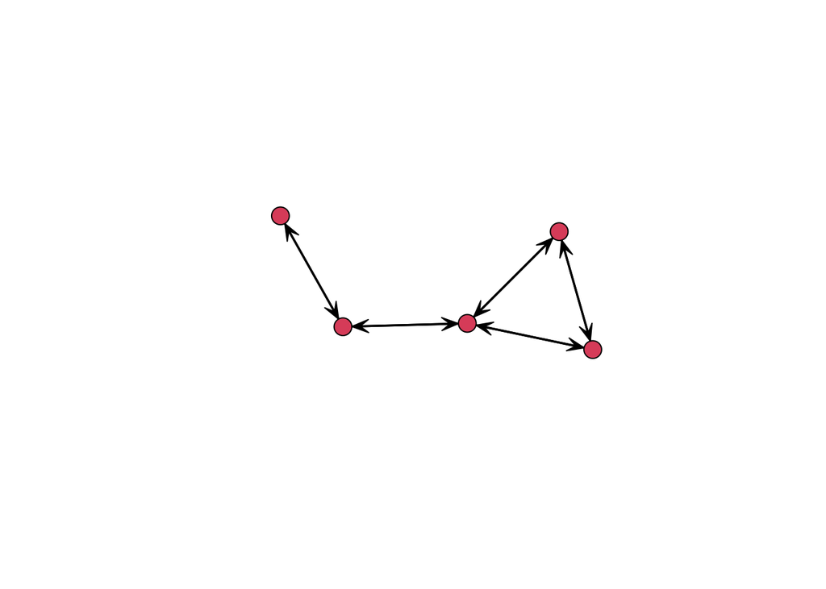

```r
# First, clear the workspace
rm( list = ls() )

# Then, build an object
u.mat <- rbind(
  c( 0,1,0,0,0 ),
  c( 1,0,1,0,0 ),
  c( 0,1,0,1,1 ),
  c( 0,0,1,0,1 ),
  c( 0,0,1,1,0 ) )

# Assign the names to the object
rownames( u.mat ) <- c( "Jen","Tom","Bob","Leaf","Jim" )
colnames( u.mat ) <- c( "Jen","Tom","Bob","Leaf","Jim" )

# Now, plot the graph (remember to load the sna package)
# The quitely= argument tells R not to print out the info on the package
library( sna, quietly=TRUE )

# Let's set up the coordinates to force the nodes
# to be in the same position throughout the lab
set.seed( 605 )
coords <- gplot( u.mat )
```

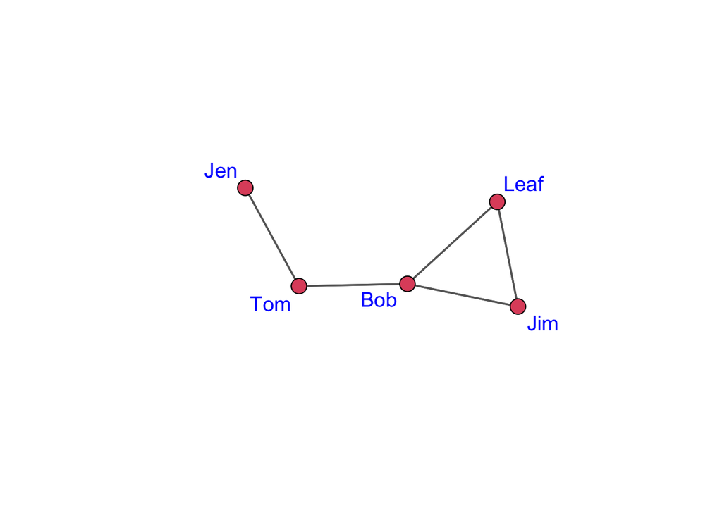

```r
# Plot the network
gplot(
  u.mat,
  gmode="graph",
  arrowhead.cex=0.5,
  edge.col="grey40",
  label=rownames( u.mat ),
  label.col="blue",
  label.cex=1.2,
  coord = coords
  )
```

Since the graph is undirected, we can print the degree centrality for each node as a vector using the `colSums()` or `rowSums()` functions:

```r
colSums( u.mat )
```

```
##  Jen  Tom  Bob Leaf  Jim
##    1    2    3    2    2
```

```r
rowSums( u.mat )
```

```
##  Jen  Tom  Bob Leaf  Jim
##    1    2    3    2    2
```

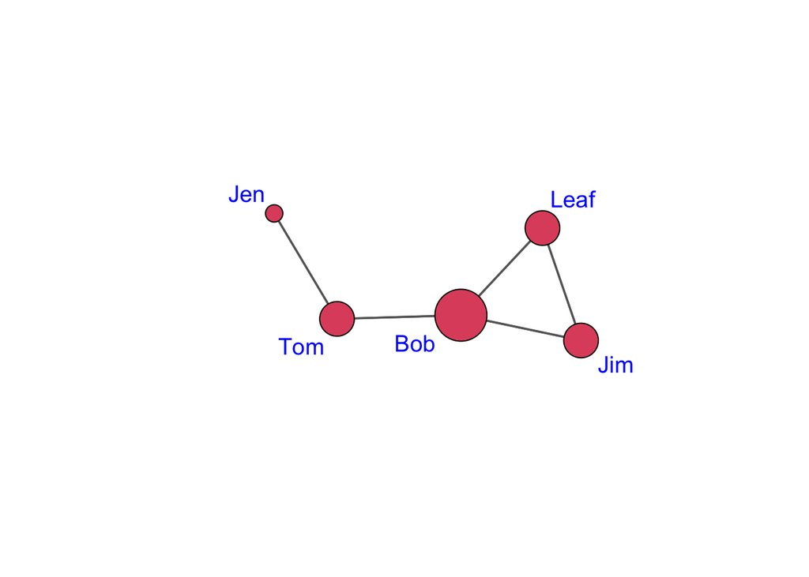

```r
# We could also assign these to an object
deg.u.mat <- colSums( u.mat )

# Then, use that information in the plot
# Use the vertex.cex= argument to pass the degree
# This will make nodes with higher degree larger
gplot(
  u.mat,
  gmode="graph",
  arrowhead.cex=0.5,
  edge.col="grey40",
  label=rownames( u.mat ),
  label.col="blue",
  label.cex=1.2,
  vertex.cex = deg.u.mat,
  coord = coords
  )
```

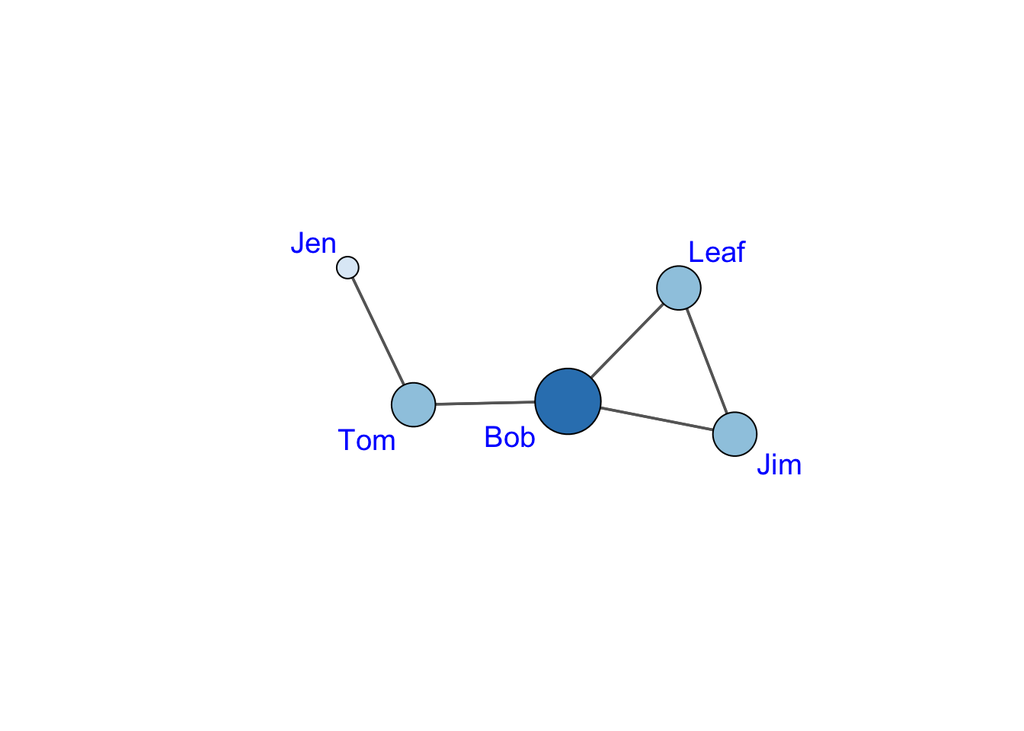

```r
# Or, we could use the RColorBrewer package to shade the nodes

# install.packages( "RColorBrewer" )
library( RColorBrewer, quietly=TRUE )

# use display.brewer.all() to see the pallettes.

# Let's use the Blues pallette.
col.deg  <- brewer.pal( length( unique( deg.u.mat ) ), "Blues")[deg.u.mat]

# In this plot, what do darker shades mean?
gplot(
  u.mat,
  gmode="graph",
  arrowhead.cex=0.5,
  edge.col="grey40",
  label=rownames( u.mat ),
  label.col="blue",
  label.cex=1.2,
  vertex.cex = deg.u.mat,
  vertex.col = col.deg,
  coord = coords
  )
```

#### **Standardized degree centrality, mean degree, and centralization**

Actor degree centrality not only reflects each node’s connectivity to other nodes but also depends on the size of the network, *g*. As a result, larger networks will have a higher maximum possible degree centrality values. This makes comparison across networks problematic. The solution is to take into account the number of nodes and the maximum possible nodes to which *i* could be connected, *g-1*.

Let’s calculate the standardized centrality scores for our undirected graph:

```r
# unstandardized or raw centrality
deg.u.mat <- colSums( u.mat )

# to calculate g-1, we need to know the number of nodes in the graph
# this is the first dimension of the matrix
g <- dim( u.mat )[1]

# now, divide by g-1
s.deg.u.mat <- deg.u.mat / ( g-1 )

deg.u.mat
```

```
##  Jen  Tom  Bob Leaf  Jim
##    1    2    3    2    2
```

```r
s.deg.u.mat
```

```
##  Jen  Tom  Bob Leaf  Jim
## 0.25 0.50 0.75 0.50 0.50
```

We can also examine the *average* degree of the graph using

$$\frac{\sum_{i=1}^g d(n_i)}{g}$$
or

$$\frac{2L}{g}$$

where *L* is the number of edges in the graph:

```r
mean.deg <- sum( deg.u.mat ) / dim( u.mat )[1]

mean.deg
```

```
## [1] 2
```

```r
# Note that we can also use the mean() function to return this information:
mean( deg.u.mat )
```

```
## [1] 2
```

We can also calculate how centralized the graph itself is. *Group degree centralization* measures the extent to which the actors in a social network differ from one another in their individual degree centralities. Following [Wasserman & Faust (1994)](https://www.cambridge.org/core/books/social-network-analysis/90030086891EB3491D096034684EFFB8), an index of *group degree centralization* can be calculated as:

$$C_D = \frac{\sum\limits_{i=1}^g
[C_D(n^*) - C_D(n_i)]}{[(g-1)(g-2)]}$$

for undirected graphs where $C_D(n^*)$ is the maximum degree in the graph. We can write out the components of the equation using the `max()` function:

```r
# In separate pieces
deviations <- max( deg.u.mat ) - deg.u.mat
sum.deviations <- sum( deviations )
numerator <- sum.deviations
denominator <- ( g-1 )*( g-2 )
group.deg.cent <- numerator/denominator

group.deg.cent
```

```
## [1] 0.4166667
```

```r
# Or, as a single equation.
group.deg.cent <-( sum( ( ( max( deg.u.mat ) - deg.u.mat ) ) ) ) / ( ( g -1 )*( g - 2 ) )

group.deg.cent
```

```
## [1] 0.4166667
```

### **Degree Centrality (Directed Binary Graphs)**

In a directed binary graph, actor degree centrality can be broken down into *indegree* and *outdegree* centrality. Indegree, $C_I(n_i)$, measures the number of ties that *i* receives. For the sociomatrix $Xij$, the indegree for *i* is the **column** sum. Outdegree, $C_O(n_i)$, measures the number of ties that *i* sends. For the sociomatrix $Xij$, the outdegree for *i* is the **row** sum.

As before, if we have an object of `class(matrix)` in the workspace, we can use the `rowSums()` and `colSums()` functions. However, the `colSums()` function will return the *indegree* centrality for *i* and the `rowSums()` function will return the *outdegree* centrality for *i*.

First, let’s set up our directed graph from the degree centrality lecture:

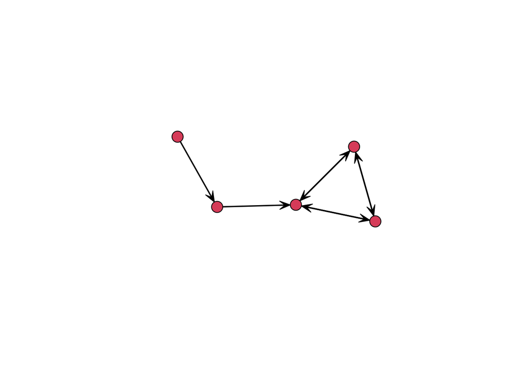

```r
# First, clear the workspace
rm( list = ls() )

# Then, build the object
d.mat <- rbind(
  c( 0,1,0,0,0 ),
  c( 0,0,1,0,0 ),
  c( 0,0,0,1,1 ),
  c( 0,0,1,0,1 ),
  c( 0,0,1,1,0 ) )
rownames( d.mat ) <- c( "Jen","Tom","Bob","Leaf","Jim" )
colnames( d.mat ) <- c( "Jen","Tom","Bob","Leaf","Jim" )

# Let's set up the coordinates to force the nodes
# to be in the same position throughout the lab
set.seed( 605 )

# remove the old object named coords
rm( coords )

# set the new coordinates
coords <- gplot( d.mat )
```

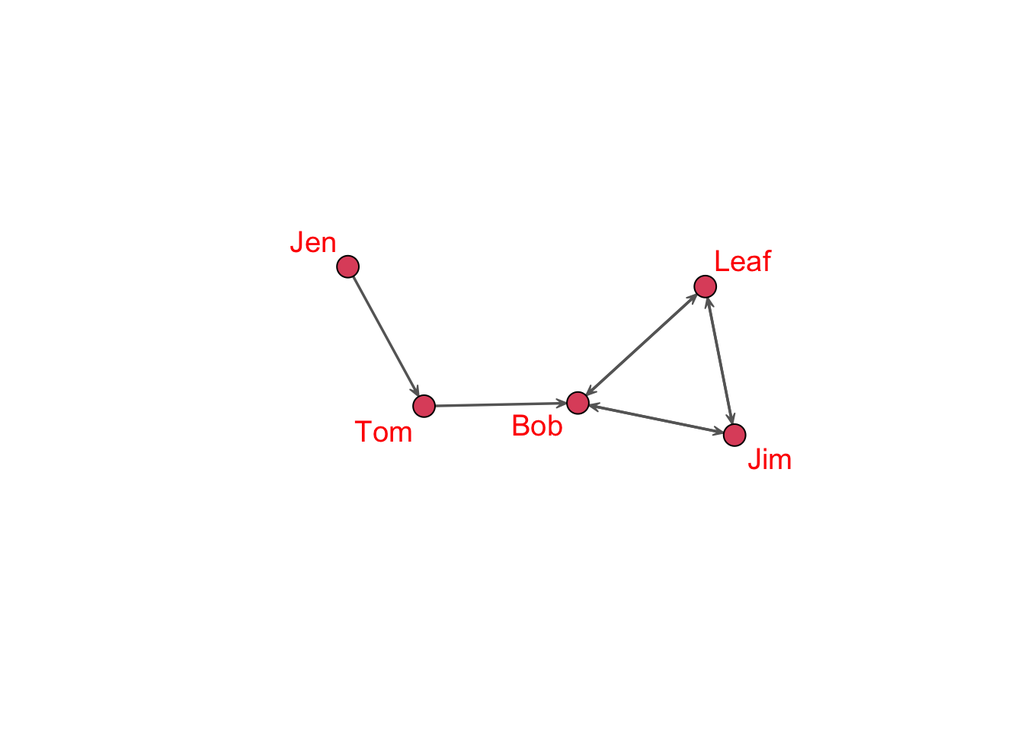

```r
# Now, plot the graph (remember to load the sna package)
gplot(
  d.mat,
  gmode="digraph",
  arrowhead.cex=0.5,
  edge.col="grey40",
  label=rownames( d.mat ),
  label.col="red",
  label.cex=1.2,
  coord = coords
  )
```

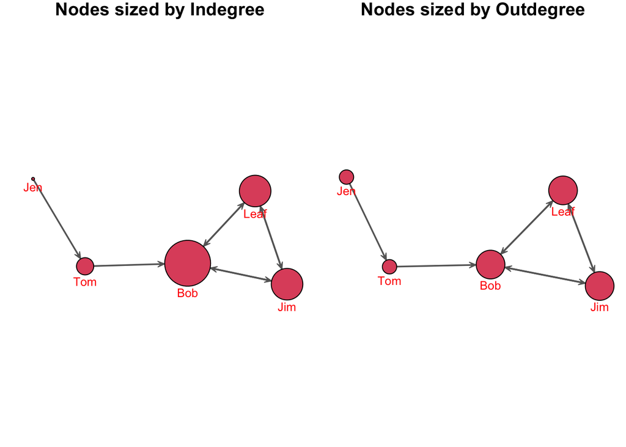

```r
# Let's look at the different centrality scores
# by assigning them to different objects
ideg.d.mat <- colSums( d.mat )
odeg.d.mat <- rowSums( d.mat )

# Then, use that information in the plot
# partition the plotting window using
# the par() function to show two plots
# change the margins using the mar= argument
par(
  mfrow=c( 1, 2 ),
  mar=c( 0.1, 0.5, 1, 0.1)
  )

gplot(
  d.mat,
  gmode="digraph",
  arrowhead.cex=0.5,
  edge.col="grey40",
  label=rownames( d.mat ),
  label.col="red",
  label.cex=0.8,
  label.pos=1,
  vertex.cex = ideg.d.mat+0.2,
  main="Nodes sized by Indegree",
  coord = coords
  )

gplot(
  d.mat,
  gmode="digraph",
  arrowhead.cex=0.5,
  edge.col="grey40",
  label=rownames( d.mat ),
  label.col="red",
  label.cex=0.8,
  label.pos=1,
  vertex.cex = odeg.d.mat,
  main="Nodes sized by Outdegree",
  coord = coords
  )
```

```r
# return plot partition to 1 pane
par( mfrow=c( 1,1 ) )
```

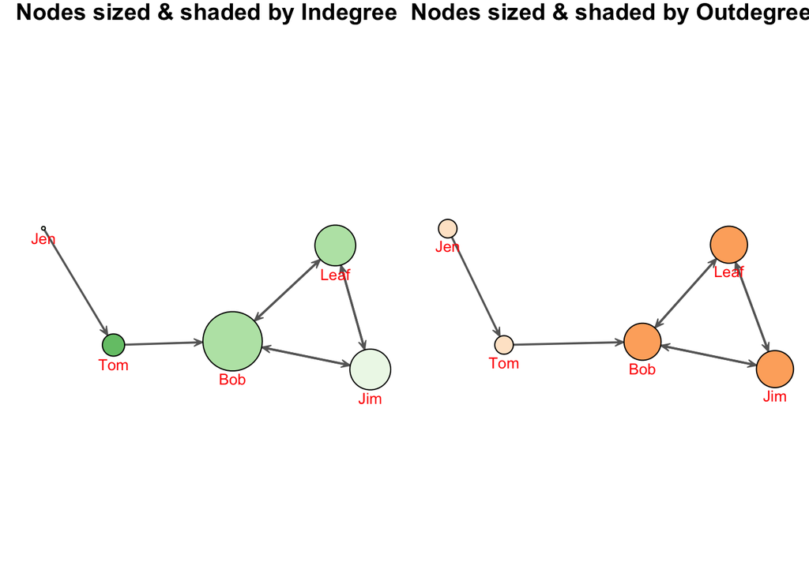

```r
# Or, we could use the RColorBrewer package to shade the nodes
library( RColorBrewer, quietly=TRUE )


# create the objects
col.ideg  <- brewer.pal( length( unique( ideg.d.mat ) ), "Greens")[ideg.d.mat]
col.odeg  <- brewer.pal( length( unique( odeg.d.mat ) ), "Oranges")[odeg.d.mat]


par(
  mfrow=c( 1, 2 ),
  mar=c( 0.1, 0.5, 1, 0.1)
  )

gplot(
  d.mat,
  gmode = "digraph",
  arrowhead.cex = 0.5,
  edge.col = "grey40",
  label = rownames( d.mat ),
  label.col = "red",
  label.cex = 0.8,
  label.pos = 1,
  vertex.cex = ideg.d.mat+0.2,
  vertex.col = col.ideg,
  main = "Nodes sized & shaded by Indegree",
  coord = coords
  )

gplot(
  d.mat,
  gmode = "digraph",
  arrowhead.cex = 0.5,
  edge.col = "grey40",
  label = rownames( d.mat ),
  label.col = "red",
  label.cex = 0.8,
  label.pos = 1,
  vertex.cex = odeg.d.mat,
  vertex.col = col.odeg,
  main = "Nodes sized & shaded by Outdegree",
  coord = coords
  )
```

```r
# return plot partition to 1 pane
par( mfrow=c( 1,1 ) )
```

#### **Standardized degree centrality, mean degree, and centralization**

Let’s calculate the standardized centrality scores for our directed graph:

```r
# unstandardized or raw centrality
ideg.d.mat <- colSums( d.mat )
odeg.d.mat <- rowSums( d.mat )

# to calculate g-1, we need to know the number of nodes in the graph
# this is the first dimension of the matrix
g <- dim( d.mat )[1]

# now, divide by g-1
s.i.deg.u.mat <- ideg.d.mat / ( g-1 )
s.o.deg.u.mat <- odeg.d.mat / ( g-1 )
```

We can also examine the *average* degree of the graph using $\frac{\sum_{i=1}^g C_I(n_i)}{g} = \frac{\sum_{i=1}^g C_O(n_i)}{g}$ or $\frac{L}{g}$, where *L* is the number of edges in the graph:

```r
mean.i.deg <- sum( ideg.d.mat ) / dim( d.mat )[1]
mean.o.deg <- sum( odeg.d.mat ) / dim( d.mat )[1]
mean.i.deg
```

```
## [1] 1.6
```

```r
mean.o.deg
```

```
## [1] 1.6
```

Again, following Wasserman & Faust (1994), an index of *group indegree/outdegree centralization* can be calculated as:

$$C_D = \frac{\sum\limits_{i=1}^g
[C_D(n^*) - C_D(n_i)]}{[(g-1)^2]}$$

```r
# In separate pieces
deviations <- max( ideg.d.mat ) - ideg.d.mat
sum.deviations <- sum( deviations )
numerator <- sum.deviations
denominator <- ( g-1 )*( g-1 )
group.i.deg.cent <- numerator/denominator
group.i.deg.cent
```

```
## [1] 0.4375
```

```r
deviations <- max( odeg.d.mat ) - odeg.d.mat
sum.deviations <- sum( deviations )
numerator <- sum.deviations
denominator <- ( g-1 )*( g-1 )
group.o.deg.cent <- numerator/denominator
group.o.deg.cent
```

```
## [1] 0.125
```

```r
# Or, as a single equation
group.ideg.cent <-( sum( ( ( max( ideg.d.mat ) - ideg.d.mat ) ) ) ) / ( ( g -1 )*( g - 1) )
group.odeg.cent <-( sum( ( ( max( odeg.d.mat ) - odeg.d.mat ) ) ) ) / ( ( g -1 )*( g - 1 ) )
group.ideg.cent
```

```
## [1] 0.4375
```

```r
group.odeg.cent
```

```
## [1] 0.125
```

### **Degree Centrality using the `sna` package**

Did that feel tedious? If no, go back and do it again :)

As you probably have guessed, there *are* functions in the `sna` package that calculate degree centrality and graph centralization! In the `sna` package, these are the `degree()` and `centralization()` functions, respectively. Let’s take a look at how these work.

```r
# load the library
library( sna )

# Build the objects to work with
rm( list = ls() )

u.mat <- rbind(
  c( 0,1,0,0,0 ),
  c( 1,0,1,0,0 ),
  c( 0,1,0,1,1 ),
  c( 0,0,1,0,1 ),
  c( 0,0,1,1,0 )
  )

rownames( u.mat ) <- c( "Jen","Tom","Bob","Leaf","Jim" )

colnames( u.mat ) <- c( "Jen","Tom","Bob","Leaf","Jim" )

d.mat <- rbind(
  c( 0,1,0,0,0 ),
  c( 0,0,1,0,0 ),
  c( 0,0,0,1,1 ),
  c( 0,0,1,0,1 ),
  c( 0,0,1,1,0 )
  )

rownames( d.mat ) <- c( "Jen","Tom","Bob","Leaf","Jim" )

colnames( d.mat ) <- c( "Jen","Tom","Bob","Leaf","Jim" )


# First, let's look at degree
?degree

# degree for undirected graph
deg <- degree( u.mat, gmode="graph" )

# indegree for directed graph
ideg <- degree( d.mat, gmode="digraph", cmode="indegree" )

# outdegree for directed graph
odeg <- degree( d.mat, gmode="digraph", cmode="outdegree" )

# returns the combined centrality for each node
deg.d <- degree( d.mat, gmode="digraph" )


# Now, let's look at centralization
?centralization

# degree centralization for undirected graph
cent.u <- centralization( u.mat, degree, mode="graph" )

# indegree centralization for directed graph.
i.cent.d <- centralization( d.mat, degree, mode="digraph", cmode="indegree" )

# outdegree centralization for directed graph.
o.cent.d <- centralization( d.mat, degree, mode="digraph", cmode="outdegree" )
```

*Now, wasn’t that easier?*

##### *Please* report any needed corrections to the [Issues](https://github.com/Watts-College/crj-507-spring-2024/issues/new) page. Thanks!